# Self-Driving Car Engineer Nanodegree

### Implementation

Use the code cell (or multiple code cells, if necessary) to implement the first step of your project. Once you have completed your implementation and are satisfied with the results, be sure to thoroughly answer the questions that follow.

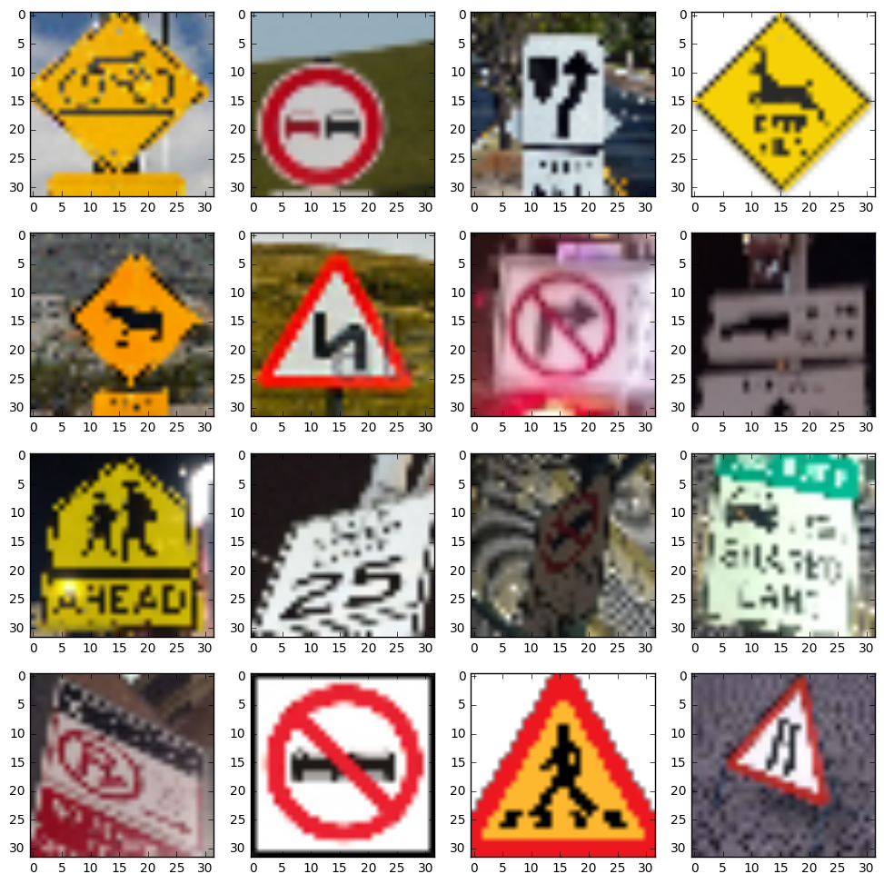

```python
### Load the images and plot them here.
### Feel free to use as many code cells as needed.

'''
I took some photos of traffic signs I found on the streets of New York City. I
zoomed into the traffic signs and cropped them out by hand at first. Then I used
OpenCV to resize them into 32x32 images.

I also found some images online and resized them into 32x32 for this challenge.
'''
import glob

imglinks = glob.glob('./challenge/*.png')

import matplotlib.image as mpimg
import cv2

if not os.path.exists('./challenge_resized'):
    os.makedirs('./challenge_resized')

fig = plt.figure()
fig.set_figwidth(12); fig.set_figheight(12)
for n, i in enumerate(imglinks):
    img = mpimg.imread(i)
    img = cv2.resize(img, (32,32))
    mpimg.imsave(os.path.join("./challenge_resized/", str(n)+".png"), img)
    ax = fig.add_subplot(4, 4, n + 1)
    ax = plt.imshow(img)
```

```python
'''
Restore my model to predict on the challenge images.
'''
challenge_data = []
for n, i in enumerate(glob.glob('./challenge_resized/*.png')):
    img = mpimg.imread(i)
    challenge_data.append(img)
challenge_data = np.array(challenge_data)[:,:,:,:3]

with tf.Session(graph=graph) as sess:
    saver = tf.train.Saver(name="saver")
    print("Restoring from file:", checkpoint_file)
    saver.restore(sess, checkpoint_file)

    feed_dict = {challenge_dataset: challenge_data}
    predictions = sess.run(challenge_prediction, feed_dict = feed_dict)
    print("\nChallenge predictions using Tianzi's model: {}".format(np.argmax(predictions, 1)))
```

```
Restoring from file: checkpoints/checkpoint_submission.chk

Challenge predictions using Tianzi's model: [ 1  9 25  2 21 10 25 40 18  4 34 21 40 39 11  0]
```

### Question 6

*Choose five candidate images of traffic signs and provide them in the report. Are there any particular qualities of the image(s) that might make classification difficult? It could be helpful to plot the images in the notebook.*

**Answer:**

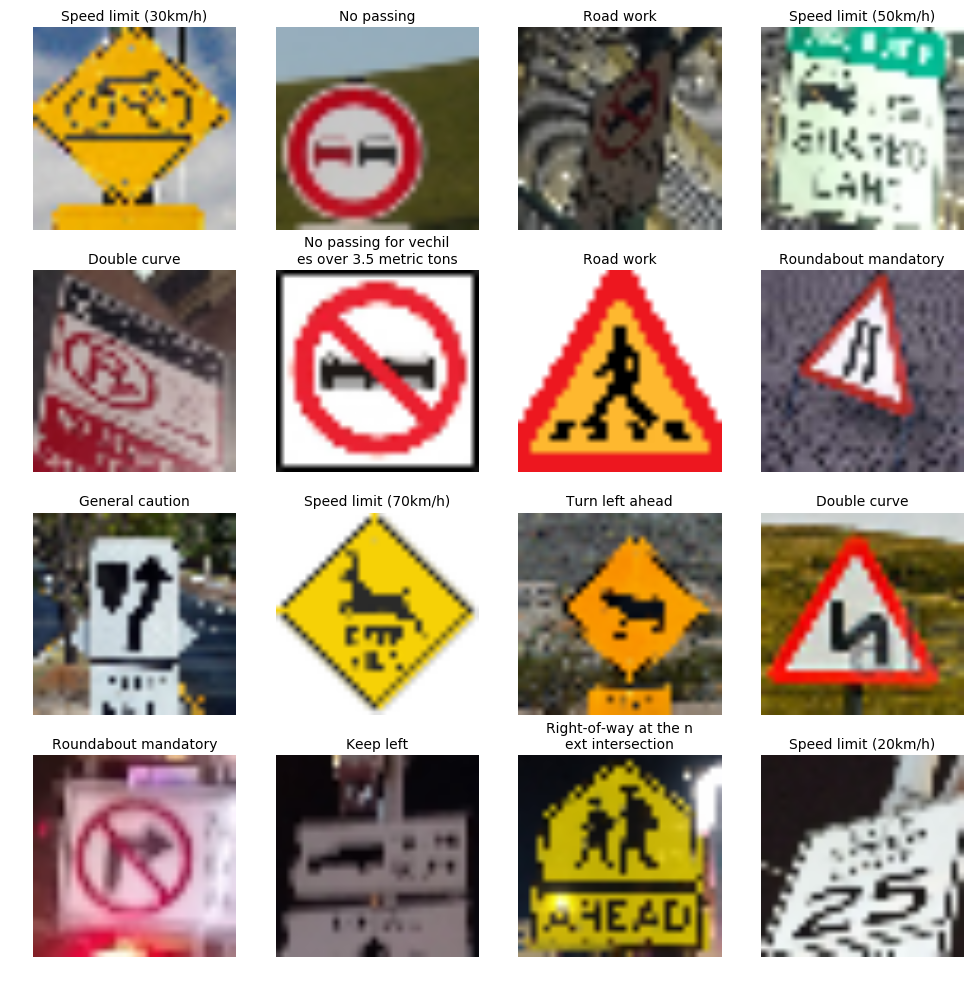

```python
### Run the predictions here.
### Feel free to use as many code cells as needed.

'''
My model did not perform very well on images that were not part of the original
testing set at all, despite giving a 95% accuracy on the test set. The only signs
that are correctly predicted below are:

Row 1, Column 2: No passing
Row 3, COlumn 4: Double curve

I give my model a little credit for predicting the last traffic sign to be a Speed
Limit sign, even though that it still gets the speed limit wrong.

I think color made it hard for my model to read traffic signs from other
countries correctly. I'm surprised that my model did not prioritize shape
over color when colors weren't matching what it had learned before. Perhaps
this is why inception model has an advantage over simpler architectures because
it uses *parallel* convolutional layers, which means that even if colors don't
match, shapes could still work independently of colors.
'''

import pandas as pd
signnames = pd.read_csv('signnames.csv', index_col='ClassId')

tz_predictions = np.argmax(predictions, 1)

fig = plt.figure()
fig.set_figwidth(12); fig.set_figheight(12)
for n, i in enumerate(challenge_data):
    title = signnames.loc[tz_predictions[n], 'SignName']
    title = title if len(title)<21 else title[:21]+'\n'+title[21:]
    ax = fig.add_subplot(4, 4, n + 1, title=title)
    ax.title.set_fontsize(10)
    plt.axis('off')
    ax = plt.imshow(i)
```

### Question 7

*Is your model able to perform equally well on captured pictures when compared to testing on the dataset? The simplest way to do this check the accuracy of the predictions. For example, if the model predicted 1 out of 5 signs correctly, it's 20% accurate.*

**NOTE:** You could check the accuracy manually by using `signnames.csv` (same directory). This file has a mapping from the class id (0-42) to the corresponding sign name. So, you could take the class id the model outputs, lookup the name in `signnames.csv` and see if it matches the sign from the image.

**Answer:**

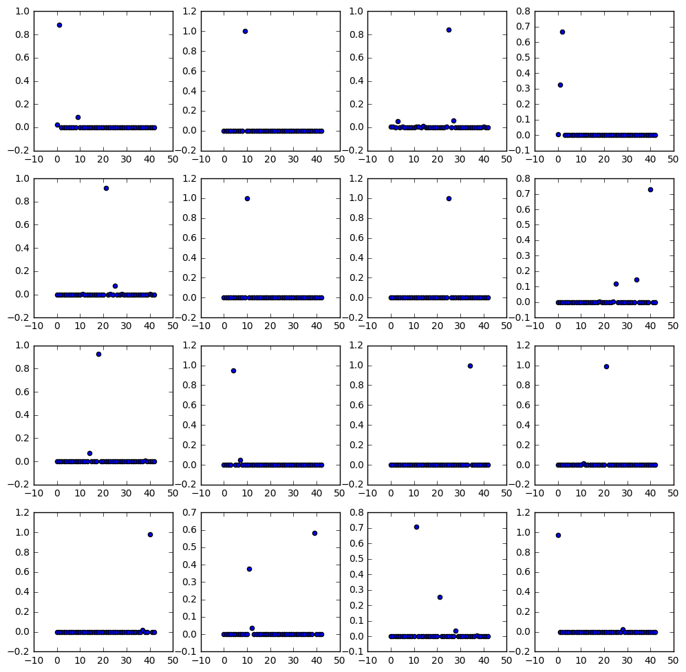

```python
### Visualize the softmax probabilities here.
### Feel free to use as many code cells as needed.

'''
My model got 2 and a half out of 16 images correctly.

Accuracy: 2.5 / 16 = 15.625%

I don't blame it for having such a low accuracy because many of the signs I test it
on are photos taken in New York City, and they are completely new to the model.

The plots show my softmax probabilities here. It looks like that most of the time,
my model is able to isolate one class to put its finger on, but not all the time,
especially for images of indices: 3, 7, 13, 14.
'''

fig = plt.figure()
fig.set_figwidth(12); fig.set_figheight(12)
for n, i in enumerate(list(predictions)):
    ax = fig.add_subplot(4, 4, n + 1)
    ax = plt.scatter(range(43), i)
```

### Question 8

*Use the model's softmax probabilities to visualize the **certainty** of its predictions, [`tf.nn.top_k`](https://www.tensorflow.org/versions/r0.12/api_docs/python/nn.html#top_k) could prove helpful here. Which predictions is the model certain of? Uncertain? If the model was incorrect in its initial prediction, does the correct prediction appear in the top k? (k should be 5 at most)*

`tf.nn.top_k` will return the values and indices (class ids) of the top k predictions. So if k=3, for each sign, it'll return the 3 largest probabilities (out of a possible 43) and the correspoding class ids.

Take this numpy array as an example:

```
# (5, 6) array
a = np.array([[ 0.24879643,  0.07032244,  0.12641572,  0.34763842,  0.07893497,
         0.12789202],
       [ 0.28086119,  0.27569815,  0.08594638,  0.0178669 ,  0.18063401,
         0.15899337],
       [ 0.26076848,  0.23664738,  0.08020603,  0.07001922,  0.1134371 ,
         0.23892179],
       [ 0.11943333,  0.29198961,  0.02605103,  0.26234032,  0.1351348 ,
         0.16505091],
       [ 0.09561176,  0.34396535,  0.0643941 ,  0.16240774,  0.24206137,
         0.09155967]])
```

Running it through `sess.run(tf.nn.top_k(tf.constant(a), k=3))` produces:

```
TopKV2(values=array([[ 0.34763842,  0.24879643,  0.12789202],
       [ 0.28086119,  0.27569815,  0.18063401],
       [ 0.26076848,  0.23892179,  0.23664738],
       [ 0.29198961,  0.26234032,  0.16505091],
       [ 0.34396535,  0.24206137,  0.16240774]]), indices=array([[3, 0, 5],
       [0, 1, 4],
       [0, 5, 1],
       [1, 3, 5],
       [1, 4, 3]], dtype=int32))
```

Looking just at the first row we get `[ 0.34763842, 0.24879643, 0.12789202]`, you can confirm these are the 3 largest probabilities in `a`. You'll also notice `[3, 0, 5]` are the corresponding indices.

**Answer:**

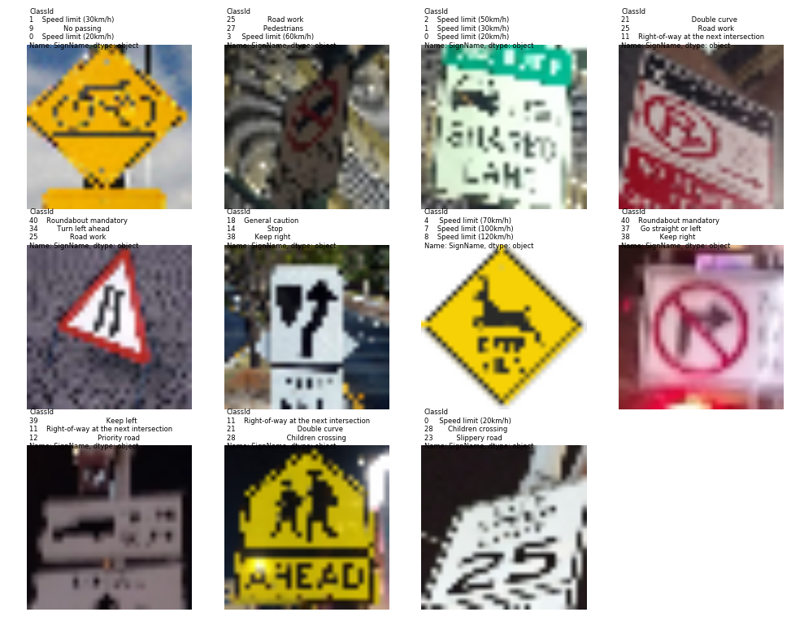

```python
'''
I selected images that my model was unsure of and printed out the top guesses
that my model had for them.

I'm pleasantly surprised that my model is "smart" enough to guess some of them
right in its top 3 guesses.

For instance, in Row 2 Column 4, the second guess says "Go straight or left",
which makes good sense.

For another instance, in Row 3 column 2, the third guess is "Children crossing".

In Row 2, Column 2, the third guess says "Keep right". Not bad.

'''

top_3 = tf.nn.top_k(tf.constant(predictions[(0,2,3,4,7,8,9,12,13,14,15),]), k=3)
session_last = tf.Session()
mytop3 = session_last.run(top_3)[1]

fig = plt.figure()
fig.set_figwidth(12); fig.set_figheight(9)
for n, i in enumerate(challenge_data[(0,2,3,4,7,8,9,12,13,14,15),]):
    text = signnames.loc[mytop3[n], 'SignName']

    ax = fig.add_subplot(3, 4, n + 1)
    ax.text(0, 0, text, fontsize = 6)
    plt.axis('off')
    ax = plt.imshow(i)
```